# R Notebook

Created a Postgresql db and loaded the table with superstore store data and the script reads the table in R

```r
library(DBI)
db <- 'practicedb'
host_db <-'localhost'
db_port <- '5432'
db_user <- 'postgres'
db_password <- 'root123'
con <- dbConnect(RPostgres::Postgres(), dbname = db, host=host_db, port=db_port, user=db_user, password=db_password)

#check if the connection is established
dbListTables(con)
```

```
[1] "superstore" "customers"  "orders"     "employees"
```

```r
#method returns an overview of the data stored in the database
df <- dbGetQuery(con, 'SELECT * FROM superstore')
head(df)
```

|  | row_id | order_id | order_date | ship_date | ship_mode | customer_id | customer_name | segment | country | city | states | postal_code | region | product_id | category | sub_category | product_name | sales | quantity | discount | profit |
| --- | --- | --- | --- | --- | --- | --- | --- | --- | --- | --- | --- | --- | --- | --- | --- | --- | --- | --- | --- | --- | --- |
| 1 | 1 | CA-2016-152156 | 2016-11-08 | 2016-11-11 | Second Class | CG-12520 | Claire Gute | Consumer | United States | Henderson | Kentucky | 42420 | South | FUR-BO-10001798 | Furniture | Bookcases | Bush Somerset Collection Bookcase | 261.960 | 2 | 0.00 | 41.9136 |
| 2 | 2 | CA-2016-152156 | 2016-11-08 | 2016-11-11 | Second Class | CG-12520 | Claire Gute | Consumer | United States | Henderson | Kentucky | 42420 | South | FUR-CH-10000454 | Furniture | Chairs | Hon Deluxe Fabric Upholstered Stacking Chairs, Rounded Back | 731.940 | 3 | 0.00 | 219.5820 |
| 3 | 3 | CA-2016-138688 | 2016-06-12 | 2016-06-16 | Second Class | DV-13045 | Darrin Van Huff | Corporate | United States | Los Angeles | California | 90036 | West | OFF-LA-10000240 | Office Supplies | Labels | Self-Adhesive Address Labels for Typewriters by Universal | 14.620 | 2 | 0.00 | 6.8714 |
| 4 | 4 | US-2015-108966 | 2015-10-11 | 2015-10-18 | Standard Class | SO-20335 | Sean O'Donnell | Consumer | United States | Fort Lauderdale | Florida | 33311 | South | FUR-TA-10000577 | Furniture | Tables | Bretford CR4500 Series Slim Rectangular Table | 957.578 | 5 | 0.45 | -383.0310 |
| 5 | 5 | US-2015-108966 | 2015-10-11 | 2015-10-18 | Standard Class | SO-20335 | Sean O'Donnell | Consumer | United States | Fort Lauderdale | Florida | 33311 | South | OFF-ST-10000760 | Office Supplies | Storage | Eldon Fold 'N Roll Cart System | 22.368 | 2 | 0.20 | 2.5164 |
| 6 | 6 | CA-2014-115812 | 2014-06-09 | 2014-06-14 | Standard Class | BH-11710 | Brosina Hoffman | Consumer | United States | Los Angeles | California | 90032 | West | FUR-FU-10001487 | Furniture | Furnishings | Eldon Expressions Wood and Plastic Desk Accessories, Cherry Wood | 48.860 | 7 | 0.00 | 14.1694 |

Checking the column names of the data, number of rows and columns

```r
names(df)
```

```
 [1] "row_id"        "order_id"      "order_date"
 [4] "ship_date"     "ship_mode"     "customer_id"
 [7] "customer_name" "segment"       "country"
[10] "city"          "states"        "postal_code"
[13] "region"        "product_id"    "category"
[16] "sub_category"  "product_name"  "sales"
[19] "quantity"      "discount"      "profit"
```

```r
nrow(df)
```

```
[1] 9994
```

```r
ncol(df)
```

```
[1] 21
```

Removing NA’s

```r
na.omit(df)
```

|  | row_id | order_id | order_date | ship_date | ship_mode | customer_id | customer_name | segment | country | city | states | postal_code | region | product_id | category | sub_category | product_name | sales | quantity | discount | profit |
| --- | --- | --- | --- | --- | --- | --- | --- | --- | --- | --- | --- | --- | --- | --- | --- | --- | --- | --- | --- | --- | --- |
| 1 | 1 | CA-2016-152156 | 2016-11-08 | 2016-11-11 | Second Class | CG-12520 | Claire Gute | Consumer | United States | Henderson | Kentucky | 42420 | South | FUR-BO-10001798 | Furniture | Bookcases | Bush Somerset Collection Bookcase | 261.9600 | 2 | 0.00 | 41.9136 |
| 2 | 2 | CA-2016-152156 | 2016-11-08 | 2016-11-11 | Second Class | CG-12520 | Claire Gute | Consumer | United States | Henderson | Kentucky | 42420 | South | FUR-CH-10000454 | Furniture | Chairs | Hon Deluxe Fabric Upholstered Stacking Chairs, Rounded Back | 731.9400 | 3 | 0.00 | 219.5820 |
| 3 | 3 | CA-2016-138688 | 2016-06-12 | 2016-06-16 | Second Class | DV-13045 | Darrin Van Huff | Corporate | United States | Los Angeles | California | 90036 | West | OFF-LA-10000240 | Office Supplies | Labels | Self-Adhesive Address Labels for Typewriters by Universal | 14.6200 | 2 | 0.00 | 6.8714 |
| 4 | 4 | US-2015-108966 | 2015-10-11 | 2015-10-18 | Standard Class | SO-20335 | Sean O'Donnell | Consumer | United States | Fort Lauderdale | Florida | 33311 | South | FUR-TA-10000577 | Furniture | Tables | Bretford CR4500 Series Slim Rectangular Table | 957.5780 | 5 | 0.45 | -383.0310 |
| 5 | 5 | US-2015-108966 | 2015-10-11 | 2015-10-18 | Standard Class | SO-20335 | Sean O'Donnell | Consumer | United States | Fort Lauderdale | Florida | 33311 | South | OFF-ST-10000760 | Office Supplies | Storage | Eldon Fold 'N Roll Cart System | 22.3680 | 2 | 0.20 | 2.5164 |
| 6 | 6 | CA-2014-115812 | 2014-06-09 | 2014-06-14 | Standard Class | BH-11710 | Brosina Hoffman | Consumer | United States | Los Angeles | California | 90032 | West | FUR-FU-10001487 | Furniture | Furnishings | Eldon Expressions Wood and Plastic Desk Accessories, Cherry Wood | 48.8600 | 7 | 0.00 | 14.1694 |
| 7 | 7 | CA-2014-115812 | 2014-06-09 | 2014-06-14 | Standard Class | BH-11710 | Brosina Hoffman | Consumer | United States | Los Angeles | California | 90032 | West | OFF-AR-10002833 | Office Supplies | Art | Newell 322 | 7.2800 | 4 | 0.00 | 1.9656 |
| 8 | 8 | CA-2014-115812 | 2014-06-09 | 2014-06-14 | Standard Class | BH-11710 | Brosina Hoffman | Consumer | United States | Los Angeles | California | 90032 | West | TEC-PH-10002275 | Technology | Phones | Mitel 5320 IP Phone VoIP phone | 907.1520 | 6 | 0.20 | 90.7152 |
| 9 | 9 | CA-2014-115812 | 2014-06-09 | 2014-06-14 | Standard Class | BH-11710 | Brosina Hoffman | Consumer | United States | Los Angeles | California | 90032 | West | OFF-BI-10003910 | Office Supplies | Binders | DXL Angle-View Binders with Locking Rings by Samsill | 18.5040 | 3 | 0.20 | 5.7825 |
| 10 | 10 | CA-2014-115812 | 2014-06-09 | 2014-06-14 | Standard Class | BH-11710 | Brosina Hoffman | Consumer | United States | Los Angeles | California | 90032 | West | OFF-AP-10002892 | Office Supplies | Appliances | Belkin F5C206VTEL 6 Outlet Surge | 114.9000 | 5 | 0.00 | 34.4700 |

[output cut: 990 more lines]

```r
NA
```

```r
tail(df$order_date)
```

```
[1] "2017-11-17" "2014-01-21" "2017-02-26" "2017-02-26"
[5] "2017-02-26" "2017-05-04"
```

Inner join in R using merge() function

```r
df1 <-data.frame(df$order_id,df$order_date,df$ship_date)
cols1<- c("order_id","order_date","ship_date")
colnames (df1)<-cols1

df2 <- data.frame (df$order_id,df$region,df$states,df$city)
cols2 <- c("order_id","region","states","city")
colnames(df2) <-cols2

inner <- merge(x=df1,y=df2, by="order_id")
inner
```

| order_id | order_date | ship_date | region | states | city |
| --- | --- | --- | --- | --- | --- |
| CA-2014-100006 | 2014-09-07 | 2014-09-13 | East | New York | New York City |
| CA-2014-100090 | 2014-07-08 | 2014-07-12 | West | California | San Francisco |
| CA-2014-100090 | 2014-07-08 | 2014-07-12 | West | California | San Francisco |
| CA-2014-100090 | 2014-07-08 | 2014-07-12 | West | California | San Francisco |
| CA-2014-100090 | 2014-07-08 | 2014-07-12 | West | California | San Francisco |
| CA-2014-100293 | 2014-03-14 | 2014-03-18 | South | Florida | Jacksonville |
| CA-2014-100328 | 2014-01-28 | 2014-02-03 | East | New York | New York City |
| CA-2014-100363 | 2014-04-08 | 2014-04-15 | West | Arizona | Glendale |
| CA-2014-100363 | 2014-04-08 | 2014-04-15 | West | Arizona | Glendale |
| CA-2014-100363 | 2014-04-08 | 2014-04-15 | West | Arizona | Glendale |

[output cut: 990 more lines]

```r
NA
```

Left join in R using merge() function

```r
df3 <- data.frame(df$order_id,df$ship_mode,df$segment,df$category)
cols3 <-c("order_id","ship_mode","segment","category")
colnames(df3) <-cols3

df4 <- data.frame(df$order_id,df$sales,df$quantity,df$discount,df$profit)
cols4 <-c("order_id","sales","quantity","discount","profit")
colnames(df4) <-cols4

left <-merge(x=df3,y=df4,by="order_id",all.x=TRUE)
left
```

| order_id | ship_mode | segment | category | sales | quantity | discount | profit |
| --- | --- | --- | --- | --- | --- | --- | --- |
| CA-2014-100006 | Standard Class | Consumer | Technology | 377.970 | 3 | 0.00 | 109.6110 |
| CA-2014-100090 | Standard Class | Corporate | Furniture | 502.488 | 3 | 0.20 | -87.9354 |
| CA-2014-100090 | Standard Class | Corporate | Furniture | 196.704 | 6 | 0.20 | 68.8464 |
| CA-2014-100090 | Standard Class | Corporate | Office Supplies | 502.488 | 3 | 0.20 | -87.9354 |
| CA-2014-100090 | Standard Class | Corporate | Office Supplies | 196.704 | 6 | 0.20 | 68.8464 |
| CA-2014-100293 | Standard Class | Home Office | Office Supplies | 91.056 | 6 | 0.20 | 31.8696 |
| CA-2014-100328 | Standard Class | Consumer | Office Supplies | 3.928 | 1 | 0.20 | 1.3257 |
| CA-2014-100363 | Standard Class | Corporate | Office Supplies | 2.368 | 2 | 0.20 | 0.8288 |
| CA-2014-100363 | Standard Class | Corporate | Office Supplies | 19.008 | 3 | 0.20 | 6.8904 |
| CA-2014-100363 | Standard Class | Corporate | Office Supplies | 2.368 | 2 | 0.20 | 0.8288 |

[output cut: 990 more lines]

```r
df3 <- data.frame(df$order_id,df$ship_mode,df$segment,df$category)
cols3 <-c("order_id","ship_mode","segment","category")
colnames(df3) <-cols3

df4 <- data.frame(df$order_id,df$sales,df$quantity,df$discount,df$profit)
cols4 <-c("order_id","sales","quantity","discount","profit")
colnames(df4) <-cols4

right <-merge(x=df3,y=df4,by="order_id",all.y=TRUE)
right
```

| order_id | ship_mode | segment | category | sales | quantity | discount | profit |
| --- | --- | --- | --- | --- | --- | --- | --- |
| CA-2014-100006 | Standard Class | Consumer | Technology | 377.970 | 3 | 0.00 | 109.6110 |
| CA-2014-100090 | Standard Class | Corporate | Furniture | 502.488 | 3 | 0.20 | -87.9354 |
| CA-2014-100090 | Standard Class | Corporate | Furniture | 196.704 | 6 | 0.20 | 68.8464 |
| CA-2014-100090 | Standard Class | Corporate | Office Supplies | 502.488 | 3 | 0.20 | -87.9354 |
| CA-2014-100090 | Standard Class | Corporate | Office Supplies | 196.704 | 6 | 0.20 | 68.8464 |
| CA-2014-100293 | Standard Class | Home Office | Office Supplies | 91.056 | 6 | 0.20 | 31.8696 |
| CA-2014-100328 | Standard Class | Consumer | Office Supplies | 3.928 | 1 | 0.20 | 1.3257 |
| CA-2014-100363 | Standard Class | Corporate | Office Supplies | 2.368 | 2 | 0.20 | 0.8288 |
| CA-2014-100363 | Standard Class | Corporate | Office Supplies | 19.008 | 3 | 0.20 | 6.8904 |
| CA-2014-100363 | Standard Class | Corporate | Office Supplies | 2.368 | 2 | 0.20 | 0.8288 |

[output cut: 990 more lines]

Outer join in R using merge() function

```r
df3 <- data.frame(df$order_id,df$ship_mode,df$segment,df$category)
cols3 <-c("order_id","ship_mode","segment","category")
colnames(df3) <-cols3

df4 <- data.frame(df$order_id,df$sales,df$quantity,df$discount,df$profit)
cols4 <-c("order_id","sales","quantity","discount","profit")
colnames(df4) <-cols4

outer <-merge(x=df3,y=df4,by="order_id",all=TRUE)
outer
```

| order_id | ship_mode | segment | category | sales | quantity | discount | profit |
| --- | --- | --- | --- | --- | --- | --- | --- |
| CA-2014-100006 | Standard Class | Consumer | Technology | 377.970 | 3 | 0.00 | 109.6110 |
| CA-2014-100090 | Standard Class | Corporate | Furniture | 502.488 | 3 | 0.20 | -87.9354 |
| CA-2014-100090 | Standard Class | Corporate | Furniture | 196.704 | 6 | 0.20 | 68.8464 |
| CA-2014-100090 | Standard Class | Corporate | Office Supplies | 502.488 | 3 | 0.20 | -87.9354 |
| CA-2014-100090 | Standard Class | Corporate | Office Supplies | 196.704 | 6 | 0.20 | 68.8464 |
| CA-2014-100293 | Standard Class | Home Office | Office Supplies | 91.056 | 6 | 0.20 | 31.8696 |
| CA-2014-100328 | Standard Class | Consumer | Office Supplies | 3.928 | 1 | 0.20 | 1.3257 |
| CA-2014-100363 | Standard Class | Corporate | Office Supplies | 2.368 | 2 | 0.20 | 0.8288 |
| CA-2014-100363 | Standard Class | Corporate | Office Supplies | 19.008 | 3 | 0.20 | 6.8904 |
| CA-2014-100363 | Standard Class | Corporate | Office Supplies | 2.368 | 2 | 0.20 | 0.8288 |

[output cut: 990 more lines]

Pie chart

concatenates labels and pct values and stores it in variable lbls

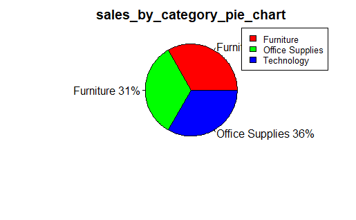

```r
# to only return sales that are positive
#df <- df[df$sales >= 0, ]
sales_by_category<- aggregate(df$sales, by=list(category=df$category), FUN=sum)


#sales_by_category<- data.frame(df$category,df$sales)
col<- c("category","sales")
colnames(sales_by_category) <- col
pct <- round(sales_by_category$sales/sum(sales_by_category$sales)*100)

labels <- df$category
lbls <-paste(labels,pct)
lbls <- paste(lbls,"%",sep="")
pie(table(sales_by_category$sales),labels=lbls,col=rainbow(3),main="sales_by_category_pie_chart")
legend("topright", sales_by_category$category, cex=0.8,fill=rainbow(length(sales_by_category$sales)))
```

The package plotrix has a function called pie3D() that is used for plotting a 3D Pie chart

explode is a parameter used to increase or decrease the gap of split in slices

```
Error in if (labelsep < minsep) { : missing value where TRUE/FALSE needed
```

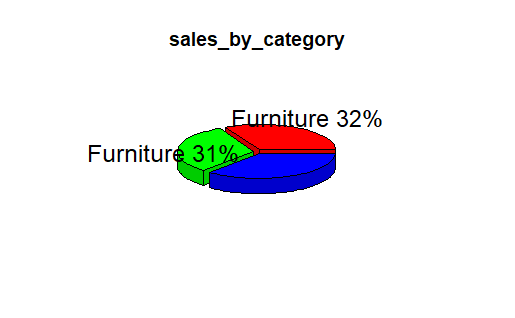

```r
#install.packages("plotrix")
library(plotrix)
pie3D(sales_by_category$sales,labels=lbls,explode=0.05,main="sales_by_category")
```

bar chart

```r
#df_bar <-head(df_bar,n=10)
#df_bar %>% top_n(10)
df_bar <-aggregate(df$sales, by=list(segment=df$category), FUN=sum)
col_bar <- c("category","sales")
colnames(df_bar) <-col_bar
df_bar
```

| category | sales |
| --- | --- |
| Furniture | 741999.8 |
| Office Supplies | 719047.0 |
| Technology | 836154.1 |

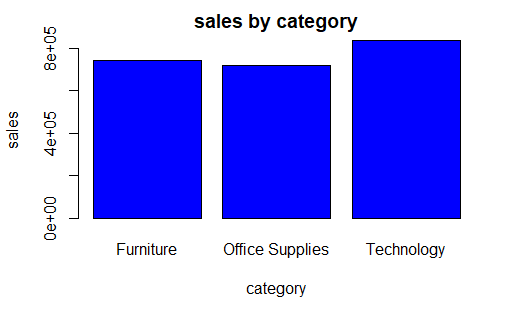

```r
barplot(df_bar$sales,xlab="category",ylab="sales",col="blue",names.arg=df_bar$category, main="sales by category")
```

```r
#legend("topright",df_bar$category,fill=c("green","yellow","orange"))
```

if statement

```r
if (as.Date("2017-11-17")%in% df$order_date) {
  print("the date is found")
}else{
  print("the date is not found")
}
```

```
[1] "the date is found"
```

if ….else.. if …else

```r
if (as.Date("2020-11-01")%in% df$order_date) {
  print("the date is found")
}else if (as.Date("2017-11-17")%in% df$order_date) {
  print ("another date is found !")
}else{
  print("the date is not found!")
}
```

```
[1] "another date is found !"
```

switch case

```r
switch_ex <- switch(
as.numeric(format(as.Date("2017-02-1"), "%m")),
 "January",
 "February",
 "March"
)
print(switch_ex)
```

```
[1] "February"
```

Repeat loop

When the break statement is encountered inside a loop, the loop is immediately terminated and program control resumes at the next statement following the loop

```r
early_date <- as.Date(df$order_date)
print( min(early_date))
```

```
[1] "2014-01-03"
```

```r
x <-as.numeric(format(as.Date(df$order_date),"%y"))
cnt <- min(x)
repeat{
  print(cnt)
cnt <- cnt+1
  if(cnt > max(x)){
    break
  }
}
```

```
[1] 14
[1] 15
[1] 16
[1] 17
```

while loop

```r
early_date <- as.Date(df$order_date)
print( min(early_date))
```

```
[1] "2014-01-03"
```

```r
x <-as.numeric(format(as.Date(df$order_date),"%y"))
cnt <- min(x)
while (cnt <max(x)) {
  print(cnt)
  cnt=cnt+1


}
```

```
[1] 14
[1] 15
[1] 16
```

for loop

```r
col<- unique(df$segment)
print(col)
```

```
[1] "Consumer"    "Corporate"   "Home Office"
```

```r
for ( i in col){
 print(i)
}
```

```
[1] "Consumer"
[1] "Corporate"
[1] "Home Office"
```

The next statement in R programming language is useful when we want to skip the current iteration of a loop without terminating it.

```r
col<- unique(df$category)
print(col)
```

```
[1] "Furniture"       "Office Supplies" "Technology"
```

```r
for ( i in col){
  if(i=="Office Supplies"){
  next
  }
 print(i)
}
```

```
[1] "Furniture"
[1] "Technology"
```

The dplyr is a powerful R-package to manipulate, clean and summarize unstructured data in a a fast way

```r
library(dplyr)

# the distinct function is used to eliminate duplicates based off the order id
df_x <- df%>%distinct(order_id,.keep_all= TRUE)
df_x
```

| row_id | order_id | order_date | ship_date | ship_mode | customer_id | customer_name | segment | country | city | states | postal_code | region | product_id | category | sub_category | product_name | sales | quantity | discount | profit |
| --- | --- | --- | --- | --- | --- | --- | --- | --- | --- | --- | --- | --- | --- | --- | --- | --- | --- | --- | --- | --- |
| 1 | CA-2016-152156 | 2016-11-08 | 2016-11-11 | Second Class | CG-12520 | Claire Gute | Consumer | United States | Henderson | Kentucky | 42420 | South | FUR-BO-10001798 | Furniture | Bookcases | Bush Somerset Collection Bookcase | 261.960 | 2 | 0.00 | 41.9136 |
| 3 | CA-2016-138688 | 2016-06-12 | 2016-06-16 | Second Class | DV-13045 | Darrin Van Huff | Corporate | United States | Los Angeles | California | 90036 | West | OFF-LA-10000240 | Office Supplies | Labels | Self-Adhesive Address Labels for Typewriters by Universal | 14.620 | 2 | 0.00 | 6.8714 |
| 4 | US-2015-108966 | 2015-10-11 | 2015-10-18 | Standard Class | SO-20335 | Sean O'Donnell | Consumer | United States | Fort Lauderdale | Florida | 33311 | South | FUR-TA-10000577 | Furniture | Tables | Bretford CR4500 Series Slim Rectangular Table | 957.578 | 5 | 0.45 | -383.0310 |
| 6 | CA-2014-115812 | 2014-06-09 | 2014-06-14 | Standard Class | BH-11710 | Brosina Hoffman | Consumer | United States | Los Angeles | California | 90032 | West | FUR-FU-10001487 | Furniture | Furnishings | Eldon Expressions Wood and Plastic Desk Accessories, Cherry Wood | 48.860 | 7 | 0.00 | 14.1694 |
| 13 | CA-2017-114412 | 2017-04-15 | 2017-04-20 | Standard Class | AA-10480 | Andrew Allen | Consumer | United States | Concord | North Carolina | 28027 | South | OFF-PA-10002365 | Office Supplies | Paper | Xerox 1967 | 15.552 | 3 | 0.20 | 5.4432 |
| 14 | CA-2016-161389 | 2016-12-05 | 2016-12-10 | Standard Class | IM-15070 | Irene Maddox | Consumer | United States | Seattle | Washington | 98103 | West | OFF-BI-10003656 | Office Supplies | Binders | Fellowes PB200 Plastic Comb Binding Machine | 407.976 | 3 | 0.20 | 132.5920 |
| 15 | US-2015-118983 | 2015-11-22 | 2015-11-26 | Standard Class | HP-14815 | Harold Pawlan | Home Office | United States | Fort Worth | Texas | 76106 | Central | OFF-AP-10002311 | Office Supplies | Appliances | Holmes Replacement Filter for HEPA Air Cleaner, Very Large Room, HEPA Filter | 68.810 | 5 | 0.80 | -123.8580 |
| 17 | CA-2014-105893 | 2014-11-11 | 2014-11-18 | Standard Class | PK-19075 | Pete Kriz | Consumer | United States | Madison | Wisconsin | 53711 | Central | OFF-ST-10004186 | Office Supplies | Storage | Stur-D-Stor Shelving, Vertical 5-Shelf: 72"H x 36"W x 18 1/2"D | 665.880 | 6 | 0.00 | 13.3176 |
| 18 | CA-2014-167164 | 2014-05-13 | 2014-05-15 | Second Class | AG-10270 | Alejandro Grove | Consumer | United States | West Jordan | Utah | 84084 | West | OFF-ST-10000107 | Office Supplies | Storage | Fellowes Super Stor/Drawer | 55.500 | 2 | 0.00 | 9.9900 |
| 19 | CA-2014-143336 | 2014-08-27 | 2014-09-01 | Second Class | ZD-21925 | Zuschuss Donatelli | Consumer | United States | San Francisco | California | 94109 | West | OFF-AR-10003056 | Office Supplies | Art | Newell 341 | 8.560 | 2 | 0.00 | 2.4824 |

[output cut: 990 more lines]

```r
NA
NA
```

```r
df_select <- distinct(df%>%select(order_id, customer_id,order_date,ship_date,ship_mode,sales,))
#df_select

df_filter <- df_select%>%filter(ship_mode=='First Class')
#df_filter

df_arrange <- df_filter%>%arrange(desc(ship_date),order_date, )
#head(df_arrange)

df_mutate <- df_arrange%>%mutate(days=as.Date(ship_date)-as.Date(order_date))
#head(df_mutate)

df_group_by <- group_by(df_mutate,days)
df_group_by
```

| order_id | customer_id | order_date | ship_date | ship_mode | sales | days |
| --- | --- | --- | --- | --- | --- | --- |
| CA-2017-101322 | JG-15310 | 2017-12-28 | 2017-12-31 | First Class | 340.7040 | 3 days |
| US-2017-102638 | MC-17845 | 2017-12-29 | 2017-12-31 | First Class | 6.0300 | 2 days |
| CA-2017-105620 | JH-15430 | 2017-12-25 | 2017-12-28 | First Class | 21.0000 | 3 days |
| CA-2017-105620 | JH-15430 | 2017-12-25 | 2017-12-28 | First Class | 120.0000 | 3 days |
| CA-2017-121195 | NS-18505 | 2017-12-24 | 2017-12-27 | First Class | 264.3200 | 3 days |
| CA-2017-120376 | TP-21130 | 2017-12-22 | 2017-12-25 | First Class | 199.9500 | 3 days |
| CA-2017-120376 | TP-21130 | 2017-12-22 | 2017-12-25 | First Class | 1586.6900 | 3 days |
| CA-2017-120376 | TP-21130 | 2017-12-22 | 2017-12-25 | First Class | 84.9900 | 3 days |
| CA-2017-120376 | TP-21130 | 2017-12-22 | 2017-12-25 | First Class | 411.8000 | 3 days |
| CA-2017-145219 | RM-19675 | 2017-12-24 | 2017-12-25 | First Class | 2879.9500 | 1 days |

[output cut: 990 more lines]

```r
NA
NA
```

inner join , right join, full join

%>% :This operator will forward a value, or the result of an expression, into the next function call/expression

```r
df3 <- data.frame(df$order_id,df$ship_mode,df$segment,df$category)
cols3 <-c("order_id","ship_mode","segment","category")
colnames(df3) <-cols3

df4 <- data.frame(df$order_id,df$sales,df$quantity,df$discount,df$profit)
cols4 <-c("order_id","sales","quantity","discount","profit")
colnames(df4) <-cols4

inner <- df3 %>% inner_join(df4,by="order_id")
# inner

right <- df3 %>% right_join(df4,by="order_id")
#right

left <-df3 %>% left_join(df4,by="order_id")
#left

outer <- df3 %>% full_join(df4,by="order_id")
outer
```

| order_id | ship_mode | segment | category | sales | quantity | discount | profit |
| --- | --- | --- | --- | --- | --- | --- | --- |
| CA-2016-152156 | Second Class | Consumer | Furniture | 261.960 | 2 | 0.00 | 41.9136 |
| CA-2016-152156 | Second Class | Consumer | Furniture | 731.940 | 3 | 0.00 | 219.5820 |
| CA-2016-152156 | Second Class | Consumer | Furniture | 261.960 | 2 | 0.00 | 41.9136 |
| CA-2016-152156 | Second Class | Consumer | Furniture | 731.940 | 3 | 0.00 | 219.5820 |
| CA-2016-138688 | Second Class | Corporate | Office Supplies | 14.620 | 2 | 0.00 | 6.8714 |
| US-2015-108966 | Standard Class | Consumer | Furniture | 957.578 | 5 | 0.45 | -383.0310 |
| US-2015-108966 | Standard Class | Consumer | Furniture | 22.368 | 2 | 0.20 | 2.5164 |
| US-2015-108966 | Standard Class | Consumer | Office Supplies | 957.578 | 5 | 0.45 | -383.0310 |
| US-2015-108966 | Standard Class | Consumer | Office Supplies | 22.368 | 2 | 0.20 | 2.5164 |
| CA-2014-115812 | Standard Class | Consumer | Furniture | 48.860 | 7 | 0.00 | 14.1694 |

[output cut: 990 more lines]

```r
NA
```